# PA 446 Midterm

Justin Valle

2026-10-16

## Load Packages

```r
library(tidyverse)
library(rvest)
library(janitor)
library(httr)
library(jsonlite)
```

```r
library(tidycensus)
library(ggplot2)
```

# Part 1: Repository and Workflow

### 1. Set up the repository.

### 2. Keep a clear commit history.

### 3. Use a branch and a pull request.

### 4. Track your work with an issue.

### 5. Publish a GitHub Page.

# Part 2: Web Scraping

## Question 1: Scrape a Table

### 1. Read the page into R and extract the table as a data frame.

### 2. Clean the column names, remove the row of citywide totals so that 77 rows remain, and convert total population to a numeric value.

### 3. Print the row for West Town, then print five community areas with the largest population.

```r
# read the elements into R
url <- "https://en.wikipedia.org/wiki/Community_areas_in_Chicago"
html <- read_html(url)
# extracting tables from Wikipedia
tables <- html |>
  html_elements("table") |>
  html_table()
# check how many tables were extracted
length(tables)
```

```
## [1] 5
```

```r
#look for population table
tables[[2]]
```

```
## # A tibble: 78 × 13
##      No. Name            `Total Population` White  `Hispanic/Latino` Black Asian
##    <int> <chr>           <chr>              <chr>  <chr>             <chr> <chr>
##  1     1 Rogers Park     54,173             24,150 12,245            11,7… 3,389
##  2     2 West Ridge      78,373             30,859 16,129            9,180 17,1…
##  3     3 Uptown          56,344             29,284 7,971             10,7… 5,831
##  4     4 Lincoln Square  41,651             25,958 7,405             1,732 3,814
##  5     5 North Center    36,014             26,413 4,267             846   2,239
##  6     6 Lake View       102,827            74,953 10,539            4,603 7,480
##  7     7 Lincoln Park    67,987             52,142 5,387             1,680 5,513
##  8     8 Near North Side 107,331            69,049 8,884             8,520 15,9…
##  9     9 Edison Park     11,558             9,181  1,724             70    187
## 10    10 Norwood Park    39,840             28,146 7,183             379   2,775
## # ℹ 68 more rows
## # ℹ 6 more variables: `Other/Multiple Races` <chr>, `% White` <dbl>,
## #   `% Hispanic/Latino` <dbl>, `% Black` <dbl>, `% Asian` <dbl>,
## #   `% Other/Multiple Races` <dbl>
```

```r
# select community areas table
community_areas <- tables[[2]]
# clean columns
community_areas <- community_areas |>
  clean_names()
# check names
names(community_areas)
```

```
##  [1] "no"                           "name"
##  [3] "total_population"             "white"
##  [5] "hispanic_latino"              "black"
##  [7] "asian"                        "other_multiple_races"
##  [9] "percent_white"                "percent_hispanic_latino"
## [11] "percent_black"                "percent_asian"
## [13] "percent_other_multiple_races"
```

```r
# remove citywide totals row
community_areas <- community_areas |>
  filter(name != "Chicago")
# convert population to numeric (must remove commas)
community_areas <- community_areas |>
  mutate(total_population = as.numeric(str_remove_all(total_population, ",")))
# check if conversion was successful
class(community_areas$total_population)
```

```
## [1] "numeric"
```

```r
# print row for West Town & print five community areas with largest pop
community_areas |>
  filter(name == "West Town")
```

```
## # A tibble: 1 × 13
##      no name      total_population white  hispanic_latino black asian
##   <int> <chr>                <dbl> <chr>  <chr>           <chr> <chr>
## 1    24 West Town            88164 54,160 17,452          5,355 5,812
## # ℹ 6 more variables: other_multiple_races <chr>, percent_white <dbl>,
## #   percent_hispanic_latino <dbl>, percent_black <dbl>, percent_asian <dbl>,
## #   percent_other_multiple_races <dbl>
```

```r
community_areas |>
  arrange(desc(total_population)) |>
  head(5)
```

```
## # A tibble: 5 × 13
##      no name            total_population white  hispanic_latino black  asian
##   <int> <chr>                      <dbl> <chr>  <chr>           <chr>  <chr>
## 1     8 Near North Side           107331 69,049 8,884           8,520  15,939
## 2     6 Lake View                 102827 74,953 10,539          4,603  7,480
## 3    25 Austin                     97452 5,452  21,212          67,261 830
## 4    24 West Town                  88164 54,160 17,452          5,355  5,812
## 5     2 West Ridge                 78373 30,859 16,129          9,180  17,104
## # ℹ 6 more variables: other_multiple_races <chr>, percent_white <dbl>,
## #   percent_hispanic_latino <dbl>, percent_black <dbl>, percent_asian <dbl>,
## #   percent_other_multiple_races <dbl>
```

```r
# check total of remaining community areas & display first 6
nrow(community_areas)
```

```
## [1] 77
```

```r
head(community_areas)
```

```
## # A tibble: 6 × 13
##      no name           total_population white  hispanic_latino black  asian
##   <int> <chr>                     <dbl> <chr>  <chr>           <chr>  <chr>
## 1     1 Rogers Park               54173 24,150 12,245          11,729 3,389
## 2     2 West Ridge                78373 30,859 16,129          9,180  17,104
## 3     3 Uptown                    56344 29,284 7,971           10,713 5,831
## 4     4 Lincoln Square            41651 25,958 7,405           1,732  3,814
## 5     5 North Center              36014 26,413 4,267           846    2,239
## 6     6 Lake View                102827 74,953 10,539          4,603  7,480
## # ℹ 6 more variables: other_multiple_races <chr>, percent_white <dbl>,
## #   percent_hispanic_latino <dbl>, percent_black <dbl>, percent_asian <dbl>,
## #   percent_other_multiple_races <dbl>
```

## Question 2: Scrape with CSS Selectors

### 1. Extract three variables using CSS selectors and combine them in a tibble with 20 rows

### 2. Convert price to a numeric variable, then save the table to your repo as books.csv

### Bonus: Add star rating of each book as a number 1 to 5

```r
# load books to scrape website
books_url <- "https://books.toscrape.com/"
books_html <- read_html(books_url)

# extract the book titles
book_titles <- books_html |>
  html_elements("article.product_pod h3 a") |>
  html_attr("title")
# check books total
length(book_titles)
```

```
## [1] 20
```

```r
# extract book prices
book_prices <- books_html |>
  html_elements("article.product_pod .price_color") |>
  html_text2()
# check price totals
length(book_prices)
```

```
## [1] 20
```

```r
# extract book availability
book_availability <- books_html |>
  html_elements("article.product_pod .availability") |>
  html_text2()
# check availability totals
length(book_availability)
```

```
## [1] 20
```

```r
# combine into tibble with 20 rows
book_info <- tibble(
  title = book_titles,
  price = book_prices,
  availability = book_availability
)
# show tibble
book_info
```

```
## # A tibble: 20 × 3
##    title                                                      price availability
##    <chr>                                                      <chr> <chr>
##  1 A Light in the Attic                                       £51.… In stock
##  2 Tipping the Velvet                                         £53.… In stock
##  3 Soumission                                                 £50.… In stock
##  4 Sharp Objects                                              £47.… In stock
##  5 Sapiens: A Brief History of Humankind                      £54.… In stock
##  6 The Requiem Red                                            £22.… In stock
##  7 The Dirty Little Secrets of Getting Your Dream Job         £33.… In stock
##  8 The Coming Woman: A Novel Based on the Life of the Infamo… £17.… In stock
##  9 The Boys in the Boat: Nine Americans and Their Epic Quest… £22.… In stock
## 10 The Black Maria                                            £52.… In stock
## 11 Starving Hearts (Triangular Trade Trilogy, #1)             £13.… In stock
## 12 Shakespeare's Sonnets                                      £20.… In stock
## 13 Set Me Free                                                £17.… In stock
## 14 Scott Pilgrim's Precious Little Life (Scott Pilgrim #1)    £52.… In stock
## 15 Rip it Up and Start Again                                  £35.… In stock
## 16 Our Band Could Be Your Life: Scenes from the American Ind… £57.… In stock
## 17 Olio                                                       £23.… In stock
## 18 Mesaerion: The Best Science Fiction Stories 1800-1849      £37.… In stock
## 19 Libertarianism for Beginners                               £51.… In stock
## 20 It's Only the Himalayas                                    £45.… In stock
```

```r
# convert price to numeric
book_info <- book_info |>
  mutate(price = as.numeric(str_remove_all(price, "£")))
# confirm price converstion and book totals
class(book_info$price)
```

```
## [1] "numeric"
```

```r
nrow(book_info)
```

```
## [1] 20
```

```r
head(book_info)
```

```
## # A tibble: 6 × 3
##   title                                 price availability
##   <chr>                                 <dbl> <chr>
## 1 A Light in the Attic                   51.8 In stock
## 2 Tipping the Velvet                     53.7 In stock
## 3 Soumission                             50.1 In stock
## 4 Sharp Objects                          47.8 In stock
## 5 Sapiens: A Brief History of Humankind  54.2 In stock
## 6 The Requiem Red                        22.6 In stock
```

```r
# save to repository as CSV
write_csv(book_info, "books.csv")

# BONUS!!!!
# add book ratings variable
book_ratings <- books_html |>
  html_elements("article.product_pod .star-rating") |>
  html_attr("class")
# remove prefix
book_ratings <- str_remove_all(book_ratings, "star-rating ")
# convert to numeric
book_ratings <- case_when(
  book_ratings == "One" ~ 1,
  book_ratings == "Two" ~ 2,
  book_ratings == "Three" ~ 3,
  book_ratings == "Four" ~ 4,
  book_ratings == "Five" ~ 5)
# add to table
book_info <- book_info |>
  mutate(star_rating = book_ratings)
book_info
```

```
## # A tibble: 20 × 4
##    title                                          price availability star_rating
##    <chr>                                          <dbl> <chr>              <dbl>
##  1 A Light in the Attic                            51.8 In stock               3
##  2 Tipping the Velvet                              53.7 In stock               1
##  3 Soumission                                      50.1 In stock               1
##  4 Sharp Objects                                   47.8 In stock               4
##  5 Sapiens: A Brief History of Humankind           54.2 In stock               5
##  6 The Requiem Red                                 22.6 In stock               1
##  7 The Dirty Little Secrets of Getting Your Drea…  33.3 In stock               4
##  8 The Coming Woman: A Novel Based on the Life o…  17.9 In stock               3
##  9 The Boys in the Boat: Nine Americans and Thei…  22.6 In stock               4
## 10 The Black Maria                                 52.2 In stock               1
## 11 Starving Hearts (Triangular Trade Trilogy, #1)  14.0 In stock               2
## 12 Shakespeare's Sonnets                           20.7 In stock               4
## 13 Set Me Free                                     17.5 In stock               5
## 14 Scott Pilgrim's Precious Little Life (Scott P…  52.3 In stock               5
## 15 Rip it Up and Start Again                       35.0 In stock               5
## 16 Our Band Could Be Your Life: Scenes from the …  57.2 In stock               3
## 17 Olio                                            23.9 In stock               1
## 18 Mesaerion: The Best Science Fiction Stories 1…  37.6 In stock               1
## 19 Libertarianism for Beginners                    51.3 In stock               2
## 20 It's Only the Himalayas                         45.2 In stock               2
```

```r
# save updated
write_csv(book_info, "books.csv")
```

# Part 3: Open Data API

### 1. Request the 1,000 most recent service requests in West Town that were created on or after January 1, 2026.

### 2. Convert the JSON response to a data frame. Print the number of rows and the column names.

### 3. Summarize. [4 points] Count the requests by sr_type and show the 10 most common request types

### 4. In 2 to 3 sentences, say what this summary suggests about service needs in West Town and name one thing the data cannot tell you.

The most frequent 311 requests made in West Town suggests that service needs of that area largely revolve around graffiti removal, rodent management, and parking code enforcement amongst other things. This data does not tell us the severity/significance of the effect the issue being requested has on residents.

### Bonus: For requests with status “Completed”, compute the median number of days between

created_date and closed_date for each of the 5 most common request types.

```r
# 311 service requests API
url_311 <- ("https://data.cityofchicago.org/resource/v6vf-nfxy.json")

# requesting the data
response_311 <- GET(
  url_311,
  query = list(
    community_area = "24",
    `$where` = "created_date >= '2026-01-01T00:00:00'",
    `$order` = "created_date DESC",
    `$limit` = 1000
  )
)
```

```r
# convert json response to dataframe
requests_311 <- fromJSON(content(response_311, "text"))
# check number of rows to ensure 1000
nrow(requests_311)
```

```
## [1] 1000
```

```r
names(requests_311)
```

```
##  [1] "sr_number"           "sr_type"             "sr_short_code"
##  [4] "owner_department"    "status"              "origin"
##  [7] "created_date"        "last_modified_date"  "street_address"
## [10] "street_number"       "street_direction"    "street_name"
## [13] "street_type"         "duplicate"           "legacy_record"
## [16] "community_area"      "ward"                "electrical_district"
## [19] "electricity_grid"    "police_sector"       "police_district"
## [22] "police_beat"         "precinct"            "created_hour"
## [25] "created_day_of_week" "created_month"       "x_coordinate"
## [28] "y_coordinate"        "latitude"            "longitude"
## [31] "location"            "city"                "state"
## [34] "zip_code"            "created_department"  "closed_date"
## [37] "parent_sr_number"
```

```r
# count requests by service type and display 10 most common
request_counts <- requests_311 |>
  count(sr_type)

#display 10 most common request types
request_counts |>
  arrange(desc(n)) |>
  head(10)
```

```
##                                    sr_type   n
## 1                 Graffiti Removal Request 200
## 2             Rodent Baiting/Rat Complaint  56
## 3               Yard Waste Pick-Up Request  48
## 4  Finance Parking Code Enforcement Review  46
## 5              Pothole in Street Complaint  36
## 6    Sign Repair Request - All Other Signs  34
## 7               Street Light Out Complaint  34
## 8                           Tree Emergency  30
## 9              Abandoned Vehicle Complaint  29
## 10                Garbage Cart Maintenance  27
```

```r
# BONUS
# find 5 most common request types
top_5_types <- requests_311 |>
  count(sr_type) |>
  arrange(desc(n)) |>
  head(5)
top_5_types
```

```
##                                   sr_type   n
## 1                Graffiti Removal Request 200
## 2            Rodent Baiting/Rat Complaint  56
## 3              Yard Waste Pick-Up Request  48
## 4 Finance Parking Code Enforcement Review  46
## 5             Pothole in Street Complaint  36
```

```r
# filter completed, calculate days, and calculate median
requests_311 |>
  filter(status == "Completed",
         sr_type %in% top_5_types$sr_type) |>
  mutate(days = as.numeric(difftime(closed_date, created_date, units = "days"))) |>
  group_by(sr_type) |>
  summarise(median_days = median(days, na.rm = TRUE))
```

```
## # A tibble: 5 × 2
##   sr_type                                 median_days
##   <chr>                                         <dbl>
## 1 Finance Parking Code Enforcement Review           0
## 2 Graffiti Removal Request                          1
## 3 Pothole in Street Complaint                       3
## 4 Rodent Baiting/Rat Complaint                      1
## 5 Yard Waste Pick-Up Request                        1
```

# Part 4: Census API

## Step 1: Identify the variables

Gross Rent as a Percentage of Household Income, “50% or more”: B25070_010E

Median Household Income: B19013_001E

## Step 2: Retrieve the data

## Step 3: Clean and transform

```r
# Retreiving 2024 ACS data for Ohio
ohio_acs <- get_acs(
  geography = "county",
  variables = c(
    rent_burden = "B25070_010",
    median_income = "B19013_001",
    rent_total = "B25070_001"
    ),
  state = "OH",
  year = 2024,
  survey = "acs5"
)
head(ohio_acs) # check results
```

```
## # A tibble: 6 × 5
##   GEOID NAME               variable      estimate   moe
##   <chr> <chr>              <chr>            <dbl> <dbl>
## 1 39001 Adams County, Ohio median_income    50264  4725
## 2 39001 Adams County, Ohio rent_total        2954   317
## 3 39001 Adams County, Ohio rent_burden        559   167
## 4 39003 Allen County, Ohio median_income    64038  1778
## 5 39003 Allen County, Ohio rent_total       13343   692
## 6 39003 Allen County, Ohio rent_burden       2537   354
```

```r
# Clean and transform the data
clean_ohioacs <- ohio_acs |>
  select(GEOID, NAME, variable, estimate) |>
  pivot_wider( # make variable column into seperate columns
    names_from = variable, # create columns from variable categories
    values_from = estimate
  )

# Calculate severe rent burden rate and sort counties
clean_ohioacs <- clean_ohioacs|>
  mutate(severe_burden_rate = (rent_burden / rent_total) * 100) |> arrange(desc(severe_burden_rate))
```

## Bonus: Split the NAME column into separate county and state columns

```r
# split name column into county and state columns
ohio_bonus <- clean_ohioacs |> # created seperate df because the new columns replaced the "name" column and I was unable to run the code again fully
  separate(NAME, into = c("county", "state"), sep = ",")

# check that county and state columns were made successfully
head(ohio_bonus)
```

```
## # A tibble: 6 × 7
##   GEOID county     state median_income rent_total rent_burden severe_burden_rate
##   <chr> <chr>      <chr>         <dbl>      <dbl>       <dbl>              <dbl>
## 1 39009 Athens Co… " Oh…         56001       9115        2751               30.2
## 2 39133 Portage C… " Oh…         75766      19481        5410               27.8
## 3 39061 Hamilton … " Oh…         72470     144332       35228               24.4
## 4 39145 Scioto Co… " Oh…         50609       9115        2194               24.1
## 5 39093 Lorain Co… " Oh…         73347      33139        7971               24.1
## 6 39017 Butler Co… " Oh…         81590      44147       10603               24.0
```

## Step 4: Analyze

1. Compute the mean and the median severe_burden_rate across counties
2. Identify the 5 counties with the highest rates and the 5 with the lowest rates

```r
# compute mean and median severe rent burden rates
clean_ohioacs |>
  summarize(
    mean_rate = mean(severe_burden_rate, na.rm = TRUE),
    median_mean = median(severe_burden_rate, na.rm = TRUE)
  )
```

```
## # A tibble: 1 × 2
##   mean_rate median_mean
##       <dbl>       <dbl>
## 1      18.3        18.7
```

```r
# 5 counties with highest rates
head(clean_ohioacs, 5)
```

```
## # A tibble: 5 × 6
##   GEOID NAME             median_income rent_total rent_burden severe_burden_rate
##   <chr> <chr>                    <dbl>      <dbl>       <dbl>              <dbl>
## 1 39009 Athens County, …         56001       9115        2751               30.2
## 2 39133 Portage County,…         75766      19481        5410               27.8
## 3 39061 Hamilton County…         72470     144332       35228               24.4
## 4 39145 Scioto County, …         50609       9115        2194               24.1
## 5 39093 Lorain County, …         73347      33139        7971               24.1
```

```r
# 5 counties with lowest reates
tail(clean_ohioacs, 5)
```

```
## # A tibble: 5 × 6
##   GEOID NAME             median_income rent_total rent_burden severe_burden_rate
##   <chr> <chr>                    <dbl>      <dbl>       <dbl>              <dbl>
## 1 39159 Union County, O…        112322       5046         589              11.7
## 2 39175 Wyandot County,…         69768       2327         247              10.6
## 3 39021 Champaign Count…         75556       3629         313               8.62
## 4 39107 Mercer County, …         76782       3355         261               7.78
## 5 39121 Noble County, O…         56098        760          23               3.03
```

## Step 5: Visualize

1. Scatterplot of median household income against severe_burden_rate with a regression line, labeled axes, and an informative title.
2. Bar chart of the top 5 and bottom 5 counties from Step 4, with bars in order

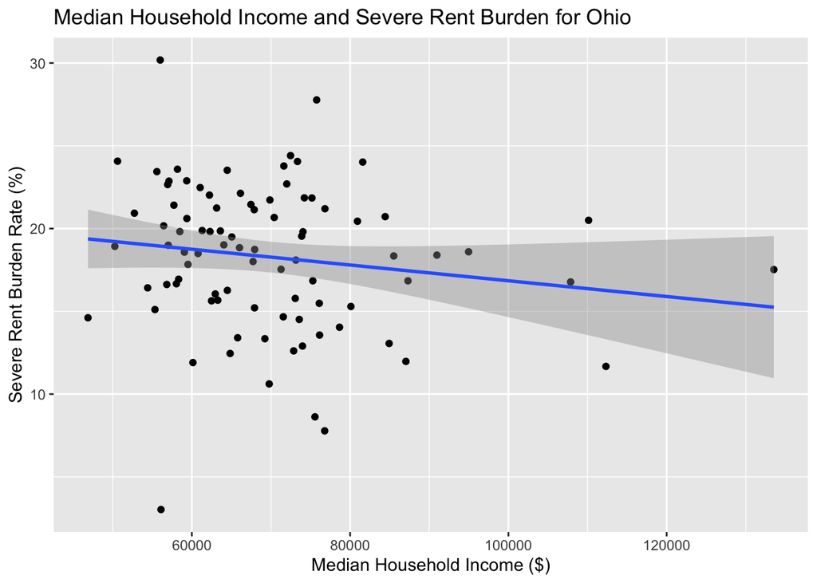

```r
# Relationship between MHI and SRB
ggplot(clean_ohioacs, aes(x = median_income, y = severe_burden_rate)) + geom_point() +
  geom_smooth(method = "lm") + # add regression line
  labs(
    title = "Median Household Income and Severe Rent Burden for Ohio",
    x = "Median Household Income ($)",
    y = "Severe Rent Burden Rate (%)"
  )
```

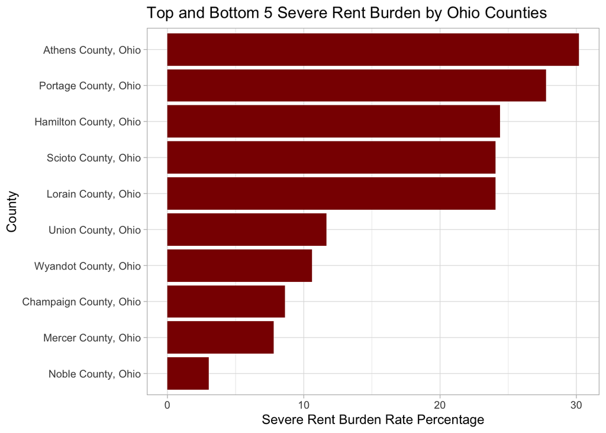

```r
# Bar chart of top 5 and bottom 5 counties
top5_bottom5_ohio <- bind_rows( # combine top 5 and bottom 5
  head(clean_ohioacs, 5),
  tail(clean_ohioacs, 5)
)
ggplot(top5_bottom5_ohio,
       aes(x = reorder(NAME, severe_burden_rate),
           y = severe_burden_rate)) +
  geom_col(fill = "darkred") +
  coord_flip() + # make bars horizontal so labels can be read
  theme_light() +
  labs(
    title = "Top and Bottom 5 Severe Rent Burden by Ohio Counties",
    x = "County",
    y = "Severe Rent Burden Rate Percentage"
  )
```

## Part 6: Reflect

#### 1. What relationships do you see between income and severe rent burden in Ohio, and what might explain it?

The scatterplot suggests a negative relationship between median household income and severe rent burden rates across Ohio counties. The relationship appears to be weak, as demonstrated by the variation of points around the regression line. A possible explanation for this could be that households in lower income areas may spend a greater portion of their income on housing costs.

#### 2. What are the two limitations of using county_level ACS estimates to decide where to target rental assistance?

For one, aggregating at the county level prevents differences between neighborhoods from being seen and understood. In other words, a county with a low severe rent burden rate could still contain neighborhoods where manny households struggle to afford rent.

Secondly, the ACS uses survey samples for their estimations population characteristics, therefore county-level estimates have margins of error that can affect accuracy between comparisons.

# Part 5: Civic Data Ethics

#### 1. Privacy. [5 points] The 311 dataset includes the street address and coordinates of each request. Suppose you wanted to publish a map of West Town requests on your GitHub Page. Identify one privacy risk, then explain how you would apply one de-identification technique before publishing.

This hypothetical brings the privacy risk of re-identification into light. Re-identification refers to the process of matching or linking de-identified data back to a specific individual by combining it with external information. Although the 311 data does not contain names, publishing exact addresses and coordinates could allow someone to identify a household associated with a complaint using other publicly available data. A fix for this could be data minimization, which emphasizes collecting and sharing only necessary information. In this context, this may look like aggregating the data by census tract in order to avoid publishing individual request locations.

#### 2. Bias and data quality. [5 points] 311 data shows where people report problems, which is not always where problems exist. Explain how this could mislead a city manager who assigns repair crews by request counts, and describe one way to check for or reduce that bias.

This question reminds me of the Boston Street Bump example used in week two. In this case civic technology was created to allow residents to report potholes via a smartphone application. Good in theory, the outcome was higher participation in wealthier, more technologically advanced neighborhoods causing neighborhoods with less smartphone access to be underrepresented. I believe this example is one that mirrors the outcomes of a city manager assigning repair crews by request counts; repair crews are allocated disproportionately and inequities are reinforced. One way to address this bias might be to interpret 311 data relative to neighborhood population sizes and assign repair crews on this basis.

#### 3. Scraping responsibly. [5 points] Using the criteria discussed in Week 5, explain whether the scraping you did in Part II was appropriate. Then describe one civic data situation where you should not scrape without further review.

Based on the criteria discussed in week 5, I believe the scraping done in part 2 was appropriate. The three conditions discussed where scraping is appropriate include: 1. The information is openly accessible, 2. the information is non personal, 3. The information is objective. The information scraped from Wikipedia was public information that did not identify private individuals. The Books to Scrape data also met both of these categories and, additionally, was intended specifically for scraping practice.

An example where scraping without further review would not be appropriate is may be scraping a government website that contains financial assistance applications including applicants names,, addresses, and household incomes. For one, this information likely requires a login or authorization. Secondly, the data has the potential to expose sensitive information about identifiable individuals.

# AI Use Statement

AI was used at times during this assignment to help identify certain functions I was unfamiliar with. This includes in part 4, where I used ChatGPT to figure out a way to ensure I had previously registered my census API key into R (Sys.getenv(“CENSUS_API_KEY”) != ““). Additionally, ChatGPT was used in part 2 to refresh my memory on where to look when inspecting a web page for specific HTML elements.